# Análisis y visualización

## Introducción

Esta sección presenta el análisis visual de la evolución de la pobreza en el Ecuador entre 2019 y 2025, utilizando los datos de la ENEMDU previamente limpiados y transformados. Para garantizar que los resultados sean representativos de la población nacional, las estimaciones se construyen utilizando el **factor de expansión (`fexp`)** proporcionado por el INEC.

## Evolución de la pobreza y pobreza extrema (2019–2025)

**Pregunta analítica:**  
¿Cómo ha evolucionado la pobreza y la pobreza extrema en el Ecuador antes y después de la pandemia?

### Visualización utilizada

[interactive chart not shown]

### Interpretación

El gráfico evidencia un quiebre significativo en el período 2020, coincidiendo con el impacto económico y social de la pandemia de COVID-19. Tanto la pobreza como la pobreza extrema aumentan de forma pronunciada respecto a 2019, pasando aproximadamente de 25 % a más de 32 % en pobreza y de 9 % a cerca de 15 % en pobreza extrema

En los años posteriores se observa una reducción gradual, aunque los niveles previos a la pandemia no se recuperan hasta 2025, lo que sugiere efectos persistentes de la crisis sobre las condiciones de vida de las personas. En 2023 y 2024 se observa una dinámica inestable, con un nuevo repunte de la pobreza y, especialmente, de la pobreza extrema en 2024.

## Diferencias entre variables demográficas

**Pregunta analítica:**  
¿Existen diferencias en los niveles de pobreza entre variables demográficas como etnia, edad o área de residencia?

### Área de residencia

[interactive chart not shown]

### Etnia

[interactive chart not shown]

### Nivel de instrucción

[interactive chart not shown]

### Grupo Etario

[interactive chart not shown]

### Interpretación

- Territorio (rural)
- Etnia (indígena, negra, afroecuatoriana)
- Educación (bajo nivel educativo)
- Ciclo de vida (niñez y vejez)

## Pobreza y condiciones laborales

**Pregunta analítica:**  
¿Cómo se relaciona la pobreza con la situación laboral de las personas?

### Pobreza por tipo de empleo

[interactive chart not shown]

### Pobreza por tipo de actividad

[interactive chart not shown]

### Interpretación

La pobreza se concentra en personas desempleadas o con empleo precario, especialmente en el sector informal. Esto muestra que no basta con tener empleo: la calidad del trabajo es un factor clave para reducir la pobreza por ingresos.

Además, la pobreza se concentra principalmente en actividades como agricultura, comercio, construcción y servicios, especialmente entre ocupaciones no calificadas. Esto evidencia que los sectores de baja productividad y alta informalidad agrupan a la mayor población pobre.

## Análisis textual

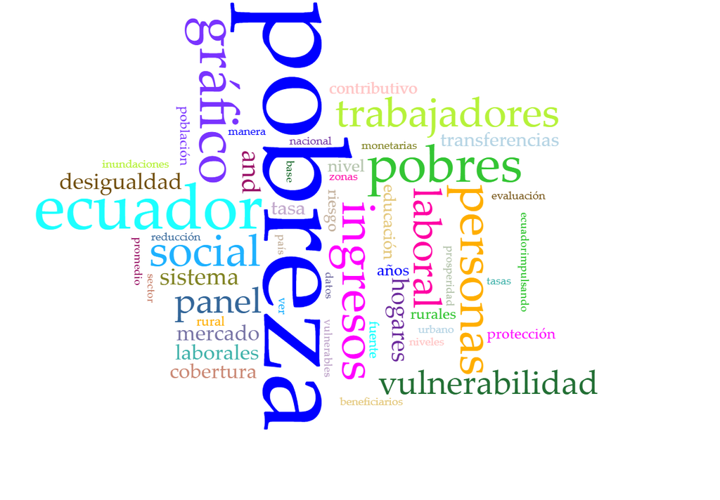

Palabras clave acerca de la pobreza

Como complemento al análisis cuantitativo, se utilizó **Voyant Tools** para explorar el lenguaje y los conceptos predominantes en documentos institucionales relacionados con pobreza y empleo.

Este análisis permite contextualizar estadísticamente los hallazgos y observar cómo el discurso institucional ha incorporado temas como vulnerabilidad, empleo y protección social en los años posteriores a la pandemia.

## Síntesis de hallazgos

Las visualizaciones presentadas permiten concluir que:

- La pandemia marca un punto de inflexión claro en la evolución de la pobreza.
- Existen desigualdades persistentes entre áreas urbanas y rurales.
- La pobreza está estrechamente vinculada a la precariedad laboral y al nivel de ingresos.
- Los patrones laborales refuerzan la necesidad de políticas diferenciadas por región y actividad de ocupación.